# TeamProject

2026-11-07

## 1. Problem Statement and Background

### Problem Definition

1.1 The central focus of this dataset is to provide insights into the factors influencing peoples’ willingness to consider purchasing an electric vehicle (EV). In particular, this dataset includes factors ranging from peoples’ age, income, and daily commute to their range anxiety level, environmental concern level, and whether or not a subsidy is available. 1.2 The target audience may include any of the following:

- Automotive Original Equipment Manufacturers (OEMs): OEMs have a vested interest in consumer behavior and trends in particular automotive subgroups. Electric vehicles are growing in popularity and charging stations are becoming more prevalent across the United States. This information may assist OEMs in determining the amount of resources they divert towards an electric fleet.
- Local City Governments: Public charging stations require investment and planning from government. This data and analysis may assist in determining to what degree charging stations should be prioritized for the benefit of their citizens.
- Electric Utilities: Power companies would benefit from knowing how prevalent EVs are and how much they’re influenced by local charging stations. If charging stations increased, there may be a change in peoples’ willingness to buy EVs, and thus increase usage on these stations.

### Data and Exploratory Analysis

The dataset includes 15 features, including numerical, categorical, and character data types. The target feature is “Will_Buy_EV” which states whether an individual will express interest in buying an EV (0 for no, 1 for yes). The data is based on a real world situation but is synthetically-generated.

Summary of Features:

| Feature | Data Type |
| --- | --- |
| **ID** | Integer |
| **Age** | Integer |
| **Annual Income USD** | Double |
| **Daily Commute (km)** | Double |
| **Number of Cars Owned** | Integer |
| **Charging Stations Near Home** | Integer |
| **Charging Stations Near Work** | Integer |
| **Environmental Concern Level** | Double |
| **Gender** | Character |
| **City Type** | Character |
| **Current Car Type** | Character |
| **Home Charging Possible** | Character |
| **Subsidy Available** | Character |
| **Range Anxiety Level** | Character |
| **Will Buy EV** | Integer |

2.2

```r
summary(train_data$Will_Buy_EV)
```

```
##      0      1
## 386268  81797
```

```r
#Proportion of Will_Buy_EV on training/validation/testing data

print("Training Data: ")
```

```
## [1] "Training Data: "
```

```r
table(train_data$Will_Buy_EV)
```

```
##
##      0      1
## 386268  81797
```

```r
prop.table(table(train_data$Will_Buy_EV))
```

```
##
##         0         1
## 0.8252444 0.1747556
```

```r
#        0         1
#   0.8252444 0.1747556

print("Validation Data: ")
```

```
## [1] "Validation Data: "
```

```r
table(val_data$Will_Buy_EV)
```

```
##
##     0     1
## 82819 17481
```

```r
prop.table(table(val_data$Will_Buy_EV))
```

```
##
##         0         1
## 0.8257129 0.1742871
```

```r
#        0         1
#   0.8257129 0.1742871

print("Testing Data: ")
```

```
## [1] "Testing Data: "
```

```r
table(test_data$Will_Buy_EV)
```

```
##
##     0     1
## 82799 17501
```

```r
prop.table(table(test_data$Will_Buy_EV))
```

```
##
##         0         1
## 0.8255135 0.1744865
```

```r
#        0         1
#   0.8255135 0.1744865

#Naive model assuming no interest in EV will have ~82.5% accuracy
```

```r
report <- data.frame(Independent_Variable = character(),
                     Correlation = numeric())
options(scipen = 999)
for (var in variables) {
  if(is.numeric(train_data[[var]])){
    cors <- cor(train_data[[var]], as.numeric(train_data$Will_Buy_EV))
    #print(paste0("Correlation between ", var, " and target: ", round(cors, 5)))
    new_report <- data.frame(Independent_Variable = var,
                             Correlation = cors)
    report <- rbind(new_report, report)
  }
}

report <- report |>
  arrange(desc(abs(Correlation)))

report
```

```
##          Independent_Variable  Correlation
## 1 Environmental_Concern_Level  0.464113219
## 2           Annual_Income_USD  0.225359786
## 3            Daily_Commute_km -0.045686603
## 4 Charging_Stations_Near_Home -0.017419123
## 5 Charging_Stations_Near_Work -0.011222110
## 6                         Age -0.007899118
## 7        Number_of_Cars_Owned  0.004208761
```

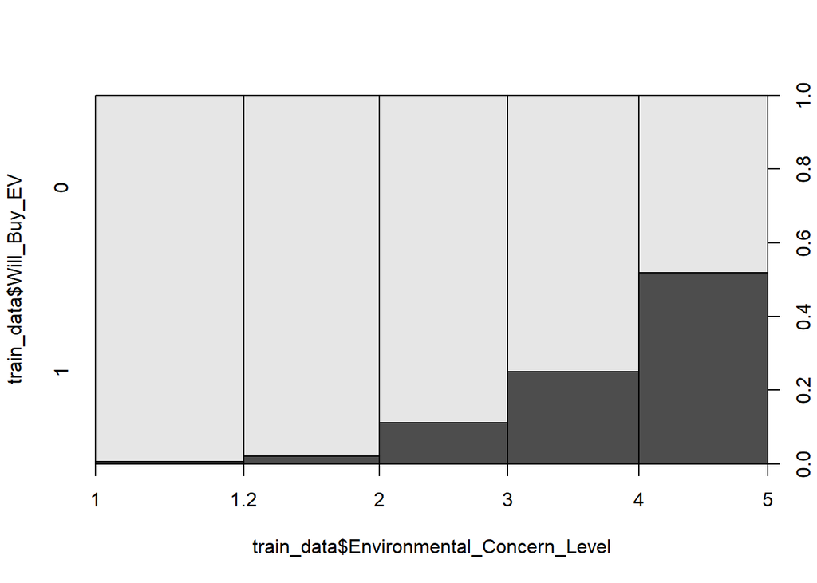

```r
#<------------------------

#Exploratory Plots
#The plot below shows that there is a positive correlation between a persons willingness of buying a EV raises when the environmental concern level
plot(train_data$Will_Buy_EV ~ train_data$Environmental_Concern_Level)
```

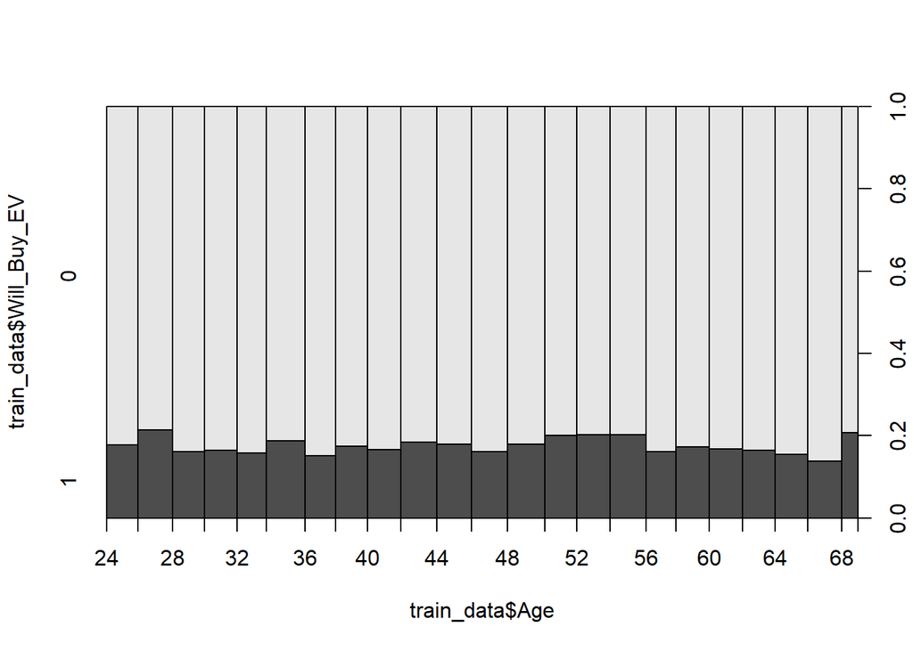

```r
#The plot below shows the correlation between buying an EV dependent on age. The correlation between the two is low to zero
plot(train_data$Will_Buy_EV ~ train_data$Age)
```

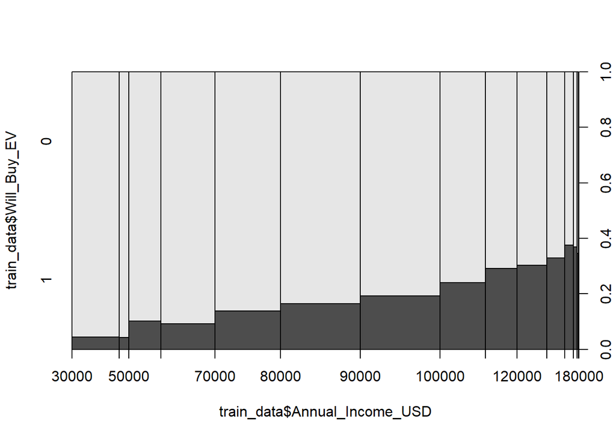

```r
#The plot below shows the correlation between buying an EV dependent on annual income. There is a small positive correlation between the two
plot(train_data$Will_Buy_EV ~ train_data$Annual_Income_USD)
```

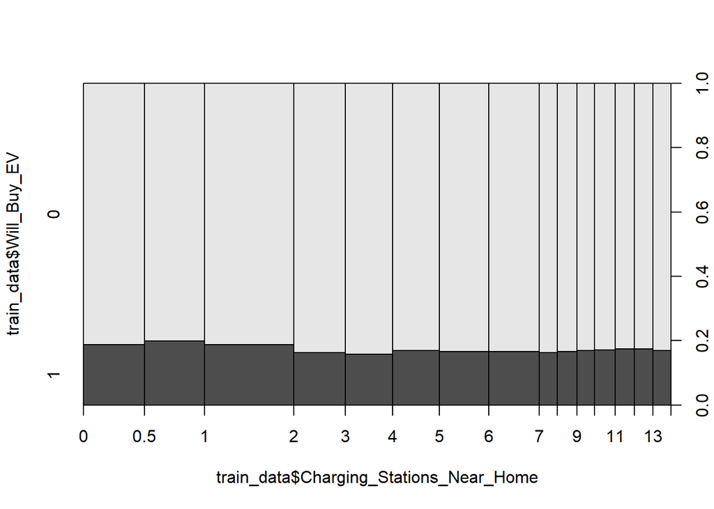

```r
#The plow below shows the correlation between buying an EV dependent on the number of charging stations near peoples house
plot(train_data$Will_Buy_EV ~ train_data$Charging_Stations_Near_Home)
```

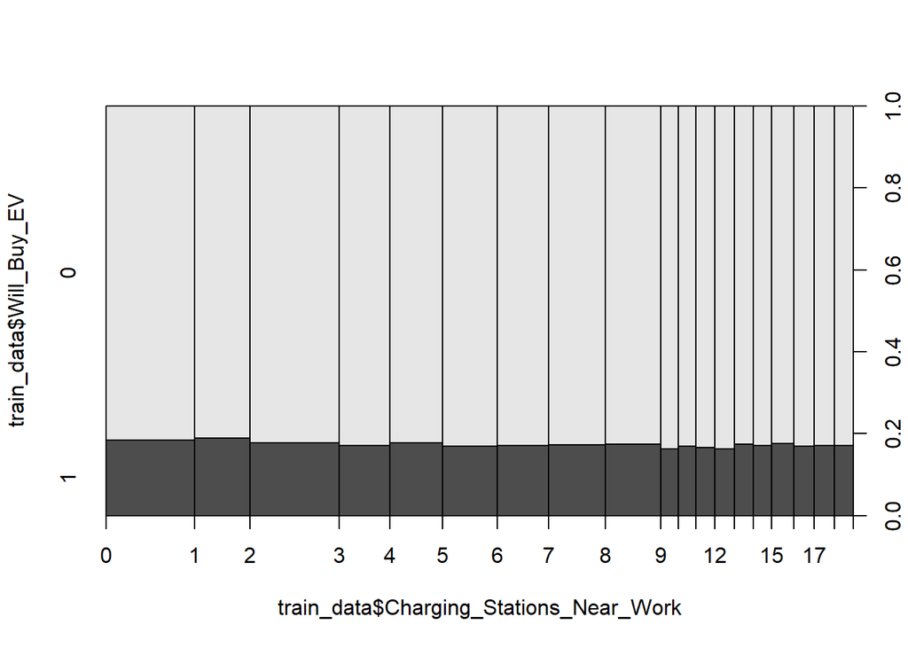

```r
#The plot below shows the correlation between buying an EV dependent on the number of charging stations near work places
plot(train_data$Will_Buy_EV ~ train_data$Charging_Stations_Near_Work)
```

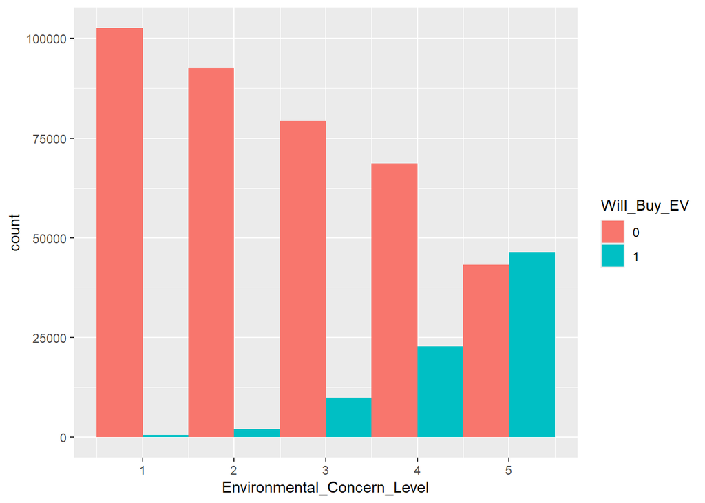

```r
#The plot below shows the counts of people buying a EV or not based on the environmental concern level
ggplot(train_data,aes(x = Environmental_Concern_Level, fill = Will_Buy_EV)) +
  geom_histogram(bins=5, position="dodge")
```

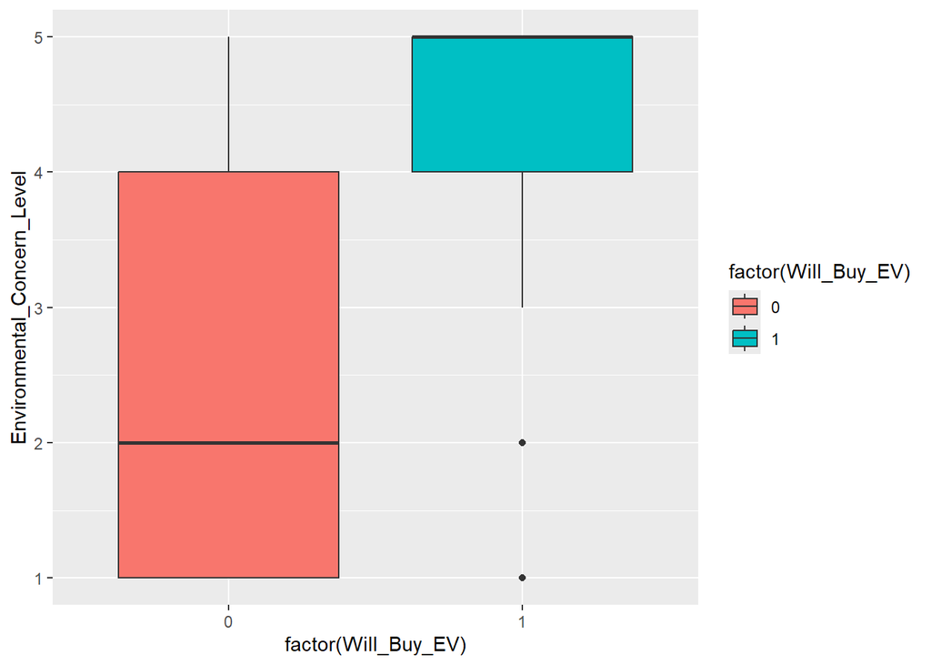

```r
#The plot below shows a boxplot showing how likely someone would buy a EV based off the environmental concern level
ggplot(train_data, aes(x = factor(Will_Buy_EV), y = Environmental_Concern_Level,
                       fill = factor(Will_Buy_EV))) +
  geom_boxplot()
```

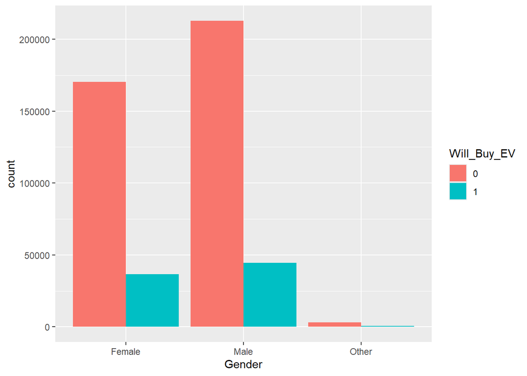

```r
#The plot below shows the count of peopleq who would but an EV split by gender
ggplot(train_data, aes(x = Gender, fill = Will_Buy_EV)) +
  geom_bar(position="dodge")
```

```r
#>------------------------
```

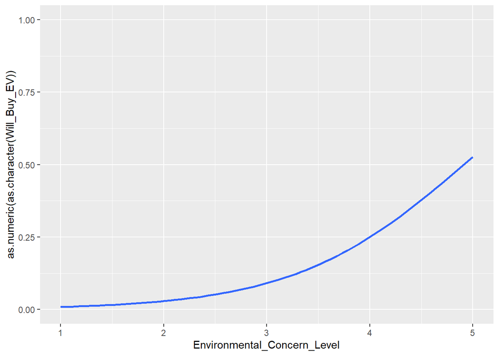

```r
model1 <- glm(reformulate(variables, response="Will_Buy_EV"), data=train_data, family=binomial(link="logit"))


ggplot(train_data, aes(x = Environmental_Concern_Level, y = as.numeric(as.character(Will_Buy_EV)))) +
  geom_smooth(method = "glm", method.args = list(family=binomial(link="logit")),
              formula = y ~ x, se = TRUE) +
  ylim(0,1)
```

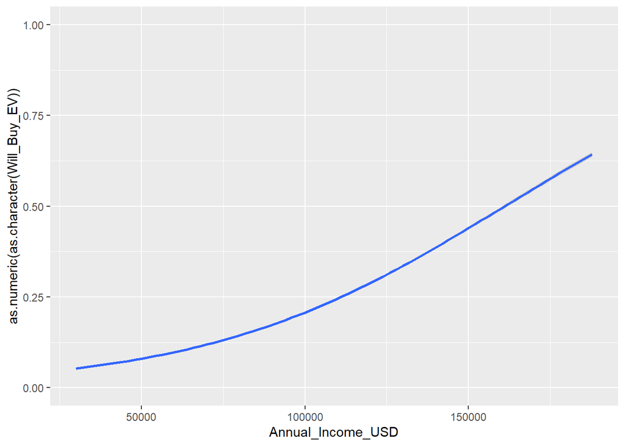

```r
ggplot(train_data, aes(x = Annual_Income_USD, y = as.numeric(as.character(Will_Buy_EV)))) +
  geom_smooth(method = "glm", method.args = list(family=binomial(link="logit")),
              formula = y ~ x, se = TRUE) +
  ylim(0,1)
```

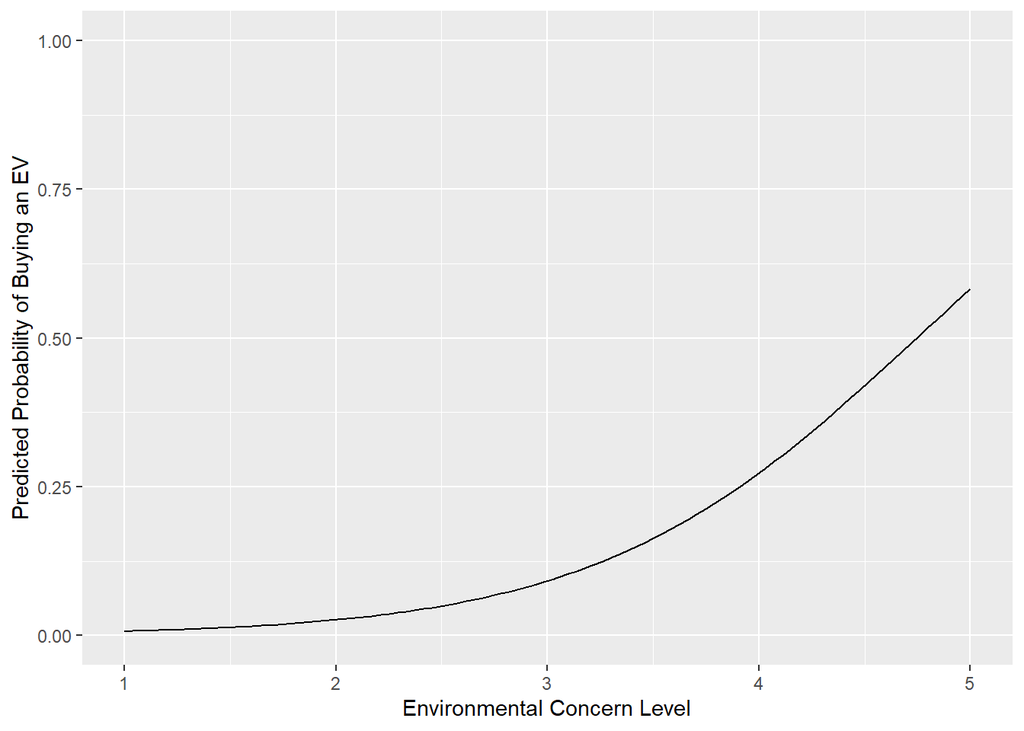

```r
#hold all variables constant - copy first row 100 times
new_data <- train_data[rep(1,100), ]

#evenly space out values for ECL across the 100 rows
new_data$Environmental_Concern_Level <- seq(
  min(train_data$Environmental_Concern_Level),
  max(train_data$Environmental_Concern_Level),
  length.out = 100
)

#produce a prediction feature
new_data$probability <- predict(model1, newdata = new_data, type="response")

#plot ECL vs predictions to see trend
ggplot(new_data, aes(x = Environmental_Concern_Level, y = probability)) +
  geom_line() +
  labs(x = "Environmental Concern Level", y = "Predicted Probability of Buying an EV") +
  ylim(0,1)
```